# Scanning many metrics with a difference-in-differences model: Power vs Low Copilot users in R

2026-07-01

# A difference-in-differences “metric scan”

## Introduction

A frequent request in Copilot Analytics is a single table that answers: *across all our collaboration metrics, on which ones do heavier Copilot users change their behaviour, by how much, and which of those changes are statistically significant?*

A naive version simply compares group means (Power users send more emails than Low users) but that is **cross-sectional** and confounded, because Power users may differ for many reasons. This notebook instead runs a **within-person difference-in-differences (DiD)** model *per metric* and assembles the results into one tidy, sortable table plus a **forest plot**. The design compares two **both-licensed** groups (**Power** vs **Low** Copilot users), so the contrast is usage *intensity*, not licence access.

For a full walk-through of a single-metric event-study and the parallel-trends assumption, see the companion `event-study-did` example. Here the focus is the **scan across metrics** and honest reporting of significance, including metrics that do **not** move.

As with the companion example, a Person Query does not ship with a clean adoption event, so we build a **small seeded simulation** whose column names match a real Person Query. Swap the simulation chunk for `vivainsights::import_query()` and the scan runs unchanged. The per-metric effects are **injected for demonstration only** and are not real results.

## Set-up

Install **fixest** with `install.packages("fixest")` if needed.

```r
knitr::opts_chunk$set(warning = FALSE, message = FALSE)
library(dplyr)
library(tidyr)
library(ggplot2)
library(scales)
library(purrr)
library(fixest)
```

## Simulate a Person-Query-shaped panel with two intensity groups

Everyone here is a licensed adopter with an adoption week; they differ in **intensity**, where **Power** users ramp to heavy Copilot use while **Low** users stay light. We simulate several standard Person Query collaboration columns and inject a *different* post-adoption change for Power vs Low on each metric. Some differentials are large, some small, and one is zero, so the scan will show a realistic mix of significant and non-significant results.

> **Replace this chunk for real data.** Load with `vivainsights::import_query()`, classify Power/Low with `vivainsights::identify_usage_segments(version = "12w")`, and derive each person’s anchor week from their first Copilot action.

```r
set.seed(202)

n_persons <- 500L
n_weeks   <- 40L
weeks     <- seq(as.Date("2024-01-01"), by = "week", length.out = n_weeks)

# ---- clearly-labelled illustrative effects --------------------------------
# DEMO ONLY: the extra post-adoption change for POWER users relative to LOW
# users, per metric. Delete / set to 0 for real data, because the model should
# estimate these, not have them baked in. Note one metric is 0 on purpose.
EFFECTS <- c(
  Emails_sent                     =  1.5,
  Chats_sent                      =  3.0,
  Meeting_hours                   =  0.4,
  Collaboration_hours             =  0.8,
  After_hours_collaboration_hours =  0.15,
  Channel_message_posts           =  0.0   # deliberately null
)
# ---------------------------------------------------------------------------

persons <- tibble(
  PersonId  = sprintf("P%04d", seq_len(n_persons)),
  group     = sample(c("Power User", "Low User"), n_persons,
                      replace = TRUE, prob = c(0.55, 0.45)),
  adopt_wk  = sample(10:26, n_persons, replace = TRUE),
  base_lvl  = rnorm(n_persons, 0, 1)          # person collaboration baseline
)

grid <- tidyr::crossing(PersonId = persons$PersonId, week_idx = seq_len(n_weeks)) |>
  left_join(persons, by = "PersonId") |>
  mutate(
    MetricDate = weeks[week_idx],
    post       = week_idx >= adopt_wk,
    is_power   = group == "Power User",
    season     = 1.2 * sin(2 * pi * week_idx / 26)
  )

# Baseline mean level per metric (rough Person Query scales)
base_mean <- c(Emails_sent = 22, Chats_sent = 30, Meeting_hours = 10,
               Collaboration_hours = 14, After_hours_collaboration_hours = 2,
               Channel_message_posts = 6)
noise_sd  <- c(Emails_sent = 5, Chats_sent = 7, Meeting_hours = 2.5,
               Collaboration_hours = 3, After_hours_collaboration_hours = 0.8,
               Channel_message_posts = 2)

simulate_metric <- function(m) {
  base_mean[[m]] + 3 * grid$base_lvl + grid$season +
    ifelse(grid$post & grid$is_power, EFFECTS[[m]], 0) +
    rnorm(nrow(grid), 0, noise_sd[[m]])
}

for (m in names(EFFECTS)) grid[[m]] <- simulate_metric(m)

panel <- grid |>
  select(PersonId, MetricDate, week_idx, group, adopt_wk, all_of(names(EFFECTS)))

head(panel)
```

```
## # A tibble: 6 × 11
##   PersonId MetricDate week_idx group      adopt_wk Emails_sent Chats_sent
##   <chr>    <date>        <int> <chr>         <int>       <dbl>      <dbl>
## 1 P0001    2024-01-01        1 Power User       16       37.2        34.4
## 2 P0001    2024-01-08        2 Power User       16       26.7        30.3
## 3 P0001    2024-01-15        3 Power User       16       32.8        42.3
## 4 P0001    2024-01-22        4 Power User       16       29.3        30.6
## 5 P0001    2024-01-29        5 Power User       16       19.0        32.5
## 6 P0001    2024-02-05        6 Power User       16        6.65       33.4
## # ℹ 4 more variables: Meeting_hours <dbl>, Collaboration_hours <dbl>,
## #   After_hours_collaboration_hours <dbl>, Channel_message_posts <dbl>
```

## Build event time and the DiD indicators

Each person’s anchor is their adoption week; we keep a balanced ±8-week window. `treated` flags Power users, `post` flags weeks on/after adoption, and their product `treat_post` is the DiD term.

```r
WINDOW <- 8L

panel_es <- panel |>
  mutate(event_week = week_idx - adopt_wk) |>
  filter(event_week >= -WINDOW, event_week <= WINDOW) |>
  group_by(PersonId) |>
  filter(sum(event_week < 0) >= 4, sum(event_week > 0) >= 4) |>
  ungroup() |>
  mutate(
    treated    = as.integer(group == "Power User"),
    post       = as.integer(event_week >= 0),
    treat_post = post * treated
  )

panel_es |> distinct(PersonId, group) |> count(group)
```

```
## # A tibble: 2 × 2
##   group          n
##   <chr>      <int>
## 1 Low User     243
## 2 Power User   257
```

## Run the DiD once per metric and collect the results

We fit `y ~ treat_post | PersonId + MetricDate` (person + week fixed effects, person-clustered SE) for every metric, then record the effect, its 95% CI, the p-value, significance stars, and the effect as a share of the Power group’s pre-adoption baseline.

```r
stars <- function(p) dplyr::case_when(
  p < 0.001 ~ "***", p < 0.01 ~ "**", p < 0.05 ~ "*", TRUE ~ "n.s."
)

run_did <- function(metric) {
  fit <- fixest::feols(
    as.formula(paste0(metric, " ~ treat_post | PersonId + MetricDate")),
    data = panel_es, cluster = ~PersonId
  )
  ct  <- fit$coeftable["treat_post", ]
  ci  <- confint(fit)["treat_post", ]
  base_pre <- mean(panel_es[[metric]][panel_es$treated == 1 & panel_es$post == 0],
                   na.rm = TRUE)
  tibble(
    metric          = metric,
    estimate        = ct[["Estimate"]],
    conf_low        = ci[[1]],
    conf_high       = ci[[2]],
    p_value         = ct[["Pr(>|t|)"]],
    sig             = stars(ct[["Pr(>|t|)"]]),
    baseline_pre    = base_pre,
    pct_of_baseline = ct[["Estimate"]] / base_pre
  )
}

results <- purrr::map_dfr(names(EFFECTS), run_did) |>
  arrange(desc(estimate))

results |>
  mutate(
    estimate        = round(estimate, 3),
    `95% CI`        = sprintf("[%+.2f, %+.2f]", conf_low, conf_high),
    `% of baseline` = scales::percent(pct_of_baseline, accuracy = 0.1),
    p_value         = signif(p_value, 2)
  ) |>
  select(Metric = metric, `Δ (units)` = estimate, `95% CI`,
         `% of baseline`, p = p_value, Sig = sig) |>
  knitr::kable(caption = "Power vs Low DiD: one row per metric, sorted by effect")
```

Power vs Low DiD: one row per metric, sorted by effect

| Metric | Δ (units) | 95% CI | % of baseline | p | Sig |
| --- | --- | --- | --- | --- | --- |
| Chats_sent | 3.144 | [+2.62, +3.67] | 10.6% | 0.0e+00 | *** |
| Emails_sent | 1.878 | [+1.49, +2.26] | 8.6% | 0.0e+00 | *** |
| Collaboration_hours | 0.786 | [+0.56, +1.01] | 5.7% | 0.0e+00 | *** |
| Meeting_hours | 0.406 | [+0.21, +0.60] | 4.1% | 4.6e-05 | *** |
| After_hours_collaboration_hours | 0.192 | [+0.13, +0.26] | 10.3% | 0.0e+00 | *** |
| Channel_message_posts | 0.120 | [-0.04, +0.28] | 2.1% | 1.4e-01 | n.s. |

Read the table as: *within-person, Power users changed this metric by `Δ` more than Low users did after adoption.* The `Sig` column separates real signals from noise, and note the deliberately null metric lands **n.s.**, which is exactly the kind of honest result this scan is meant to surface.

## Forest plot

The forest plot shows each effect as a share of the Power baseline, with 95% confidence intervals. Intervals crossing the zero line are not statistically distinguishable from “no differential change”.

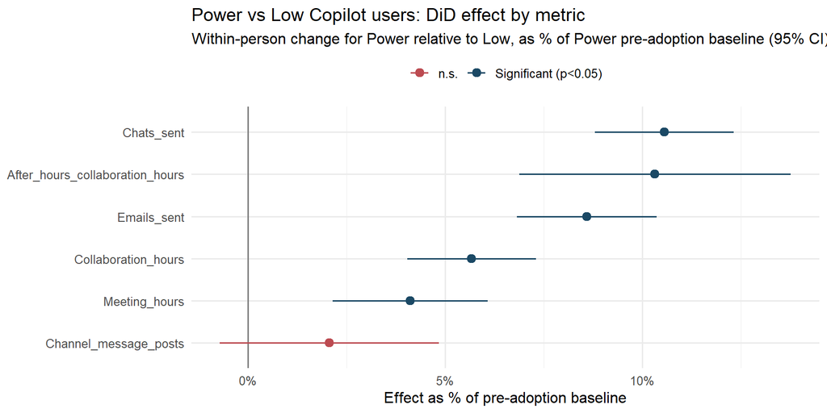

```r
ggplot(results,
       aes(x = pct_of_baseline,
           y = reorder(metric, pct_of_baseline),
           colour = sig != "n.s.")) +
  geom_vline(xintercept = 0, colour = "grey50") +
  geom_pointrange(aes(xmin = conf_low / baseline_pre,
                      xmax = conf_high / baseline_pre),
                  linewidth = 0.7, size = 0.5) +
  scale_x_continuous(labels = scales::percent) +
  scale_colour_manual(values = c(`TRUE` = "#1b4965", `FALSE` = "#bc4b51"),
                      labels = c(`TRUE` = "Significant (p<0.05)", `FALSE` = "n.s."),
                      name = NULL) +
  labs(
    title    = "Power vs Low Copilot users: DiD effect by metric",
    subtitle = "Within-person change for Power relative to Low, as % of Power pre-adoption baseline (95% CI)",
    x = "Effect as % of pre-adoption baseline", y = NULL
  ) +
  theme_minimal(base_size = 12) +
  theme(legend.position = "top")
```

## Wrapping up

Looping a DiD across metrics turns a vague “Power users collaborate more” claim into a defensible, per-metric statement with effect sizes and significance, including the honest cases where a metric does not move. To run this on your own data, replace the simulation with `vivainsights::import_query()`, define the Power and Low groups with `identify_usage_segments()`, and derive each anchor week from the first Copilot action; the scan and forest plot then work unchanged.